# Location, Cities, and Agglomeration

Module 1 · ECON 463

Jude Bayham

# Regional (and urban) economics

## Regional and urban economics

**This course blends both perspectives.**<sup>1</sup>

|  | Regional economics | Urban economics |
| --- | --- | --- |
| **Focus** | Differences and connections across regions | Why cities form and how activity is organized within them |
| **Questions** | Why do some regions grow while others decline? How do trade and migration connect places? | Why do firms and people cluster? What determines rents, density, and commuting? |
| **Topics** | Growth, specialization, migration, and regional inequality | Agglomeration, housing, land use, transport, and neighborhoods |
| **Policies** | Regional development, infrastructure, and incentives to attract employers | Zoning, transit, congestion pricing, and housing policy |

Shared ground: location choices, agglomeration, and mobility. A metropolitan area is also a region; the distinction is one of emphasis.

[^1]: Here we focus on firms choosing among cities or regions. Detailed strategic positioning relative to competitors within a city is a topic in industrial organization, with overlap in urban economics.

## Natural advantages and firm location

A resource deposit can lower input costs.

A port combines geography with built infrastructure.

A large customer base can reduce delivery costs.

## Example 1: three possible plant locations

Supply **1,000 identical units per period** to the same customers.

**Inbound:** inputs to the plant. **Outbound:** products to customers.

| Site | Production | Inbound | Outbound |
| --- | --- | --- | --- |
| Resource | 40 | 2 | 18 |
| Junction | 43 | 6 | 8 |
| Market | 48 | 10 | 2 |

All entries are **CU per unit of finished output**. Data are illustrative.

## Example 1: add the relevant costs

Let $p_i$ = production, $a_i$ = inbound, and $b_i$ = baseline outbound cost.

$$d_i(\tau)=p_i+a_i+\tau b_i,\qquad \tau=1\text{ initially}.$$

Production + inbound freight + adjusted outbound freight.

| Site | Baseline cost (CU/unit) |
| --- | --- |
| Resource | 60 |
| Junction | 57 |
| Market | 60 |

**Junction saves 3 $\times$ 1000 = 3,000 CU per period** relative to either alternative.

## Digression: Profit max or cost min

We have been focused on cost. If revenue is the same at each site:

$$\arg\max_i(R-C_i)=\arg\min_i C_i.$$

If location changes price, quality, or sales, compare **profits**.

## Digression: what if customers pay for faster delivery?

[output not shown]

**Market: 75 − 60 = 15 CU/unit**, versus Junction’s **13 CU/unit**.

Market earns **2,000 CU more profit** on the 1,000-unit order.

## Example 1: outbound freight falls by half

Set $\tau=0.5$; hold production and inbound costs fixed. Also, hold output price fixed.

| Site | Production | Inbound | Adjusted outbound | New total |
| --- | --- | --- | --- | --- |
| Resource | 40 | 2 | 18 × 0.5 = 9 | 51 |
| Junction | 43 | 6 | 8 × 0.5 = 4 | 53 |
| Market | 48 | 10 | 2 × 0.5 = 1 | 59 |

All costs are **CU per unit**. New total = production + inbound + adjusted outbound.

**Resource wins.** All sites become cheaper; their relative advantages change.

## How large does $\tau$ need to be?

The firm is indifferent between Resource and Junction when

$$42+18\tau=49+8\tau.$$

$$\tau^*=0.7,\qquad d_R=d_J=54.6.$$

Check the third site: $d_M=58+2(0.7)=59.4$.

**A pairwise tie is relevant only if no other site is cheaper.**

## Min cost location as a function of outbound cost multiplier, $\tau$

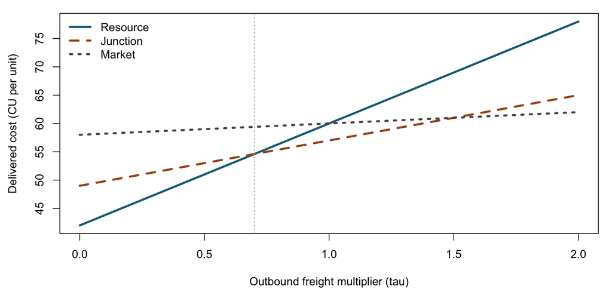

[^2]: For more explanation: reader, “Natural advantages and firm location”; Brueckner §1.4.

## Extension

Start from the **baseline costs** below; keep production and outbound costs unchanged.

| Site | Production | Baseline inbound | Outbound |
| --- | --- | --- | --- |
| Resource | 40 | 2 | 18 |
| Junction | 43 | 6 | 8 |
| Market | 48 | 10 | 2 |

## Extension: the inbound-cost lower envelope

Vary inbound costs only: $d_i(\sigma)=p_i+\sigma a_i+b_i$.

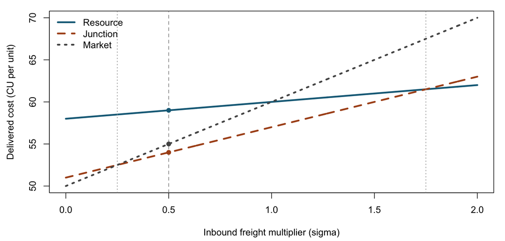

At $\sigma=0.5$: **Resource 59 · Junction 54 · Market 55 CU/unit. Junction still wins.**

# Economies of scale

## From choosing a location to choosing a scale

**Example 1:** Where should one plant locate? We took its output and production costs as given.

**Next question:** Could producing together lower costs compared with many small operations?

First explore **scale economies**.

Then bring shipping costs back into the decision.

## Scale economies

An island has **100 basket makers** and reeds available as needed (elastic supply).

Alone, each worker gathers reeds, prepares them, weaves, and packs.

In a factory, workers can specialize in different tasks.

## Scale economies: read output per worker

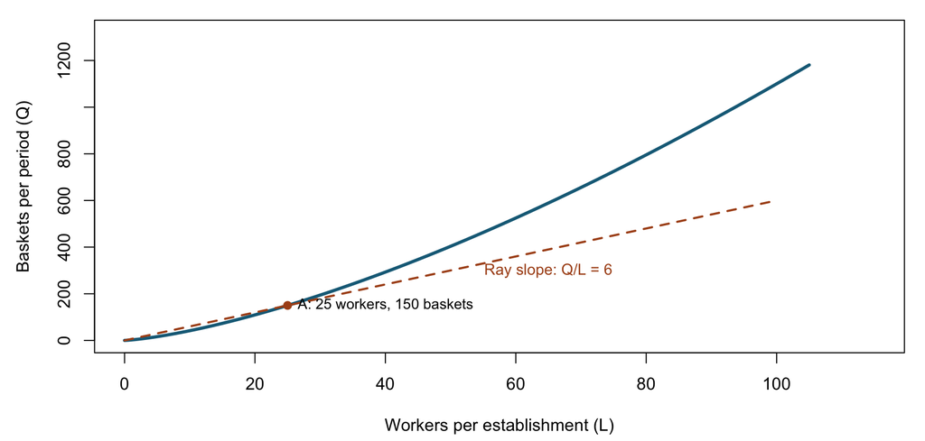

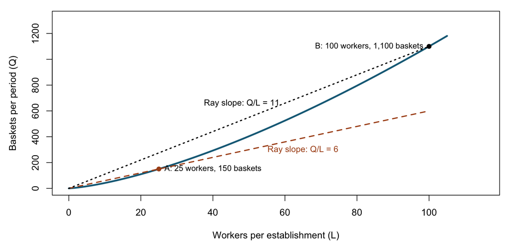

## Scale economies: compare the same workforce

| Arrangement | Plants | Workers per plant | Baskets per worker | Total baskets |
| --- | --- | --- | --- | --- |
| Separate workshops | 100 | 1 | 2 | 200 |
| One factory | 1 | 100 | 11 | 1,100 |

**Total output = plants × workers per plant × output per worker.**

Same 100 workers; greater output per worker raises total output.

## One large plant or many small plants?

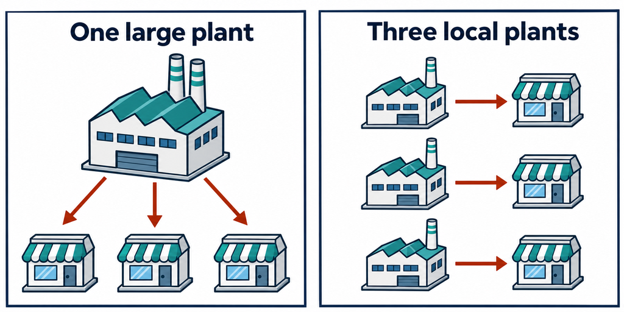

## Example 2: from output to cost

Now hold required output fixed and compare **one plant versus two**.

A plant pays fixed operating cost $F$ and $c$ per unit produced:

$$C(Q)=F+cQ,\qquad AC(Q)=F/Q+c.$$

With $F=1{,}200$ and $c=20$, production cost per unit is:

**100 units: 32 CU. 200 units: 26 CU.**

## Example 2: two markets, one order

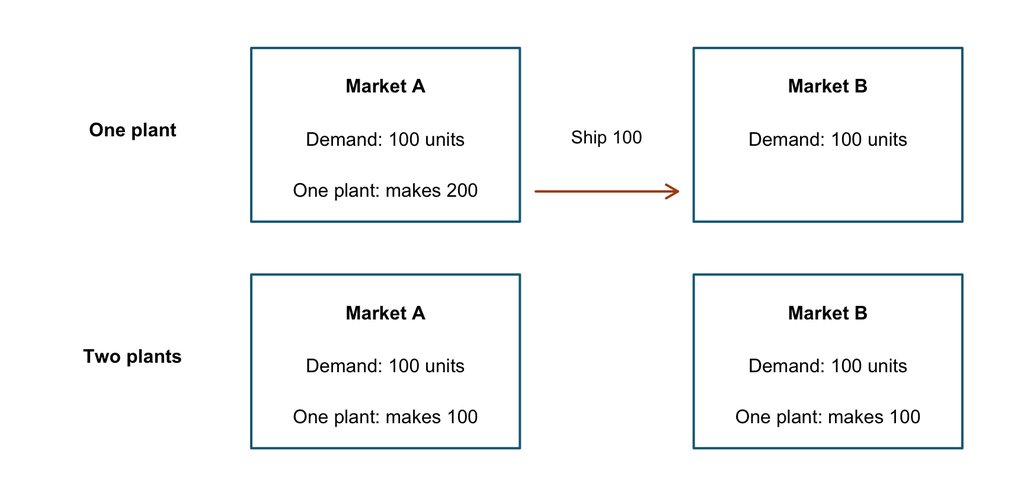

**Same revenue · identical input access · no capacity limits.**

## Example 2: first compare production

| Production costs (CU/period) | One plant | Two plants |
| --- | --- | --- |
| Fixed operating costs | 1,200 | 2,400 |
| Variable costs: 200 × 20 | 4,000 | 4,000 |
| **Total before freight** | **5,200** | **6,400** |

**One plant saves 1,200 CU: one avoidable fixed cost.**

## Example 2: now add shipping

Shipping costs **4 CU per unit** to the other market.

One plant ships 100 units: **4 × 100 = 400 CU**.

$$C_1=F+2cq+tq=1{,}200+4{,}000+400=5{,}600.$$

$$C_2=2F+2cq=2{,}400+4{,}000=6{,}400.$$

**Save 1,200 in production; spend 400 on freight. Net saving: 800 CU.**

## Example 2: when would two plants be preferred?

$$C_1-C_2= (F+2cq+tq)-(2F+2cq)=F-tq.$$

Centralize when $tq<F$; disperse when $tq>F$.

$$t^*=F/q=1{,}200/100=12\text{ CU per unit shipped}.$$

## Digression: From a large plant to a city

1. Scale economies concentrate production and jobs in a large plant.
2. Commuting time and expense encourage workers to live near those jobs.
3. Workers’ spending supports nearby shops and services.

But this example does not determine city size or explain why many independent firms cluster.<sup>1</sup>

[^3]: For more explanation: reader, “Scale economies and city formation”; Brueckner §§1.2 and 1.5.

## Costs change. Should the firm still centralize?

Keep demand at **100 units per market** and variable cost at **20 CU/unit**.

Now fixed cost falls to **600 CU per plant** and shipping costs **8 CU/unit**.

1. Predict: one plant or two?
2. Calculate each total cost. What saving must cover the freight bill?
3. Compare your reasoning with a neighbor. Why does the preferred arrangement change?

## Agglomeration mechanisms

Internal scale: change the plant’s own output.

Agglomeration: change nearby activity while holding its own scale fixed.

## Cheaper inputs: shared suppliers

Many precision-component firms support a specialist testing laboratory.

**More local customers → viable specialist → access to equipment and expertise.**

Proximity helps when samples, turnaround time, and coordination matter.

## More productive inputs: labor pooling and matching

A deep market can improve matching and reduce vacancy time.

Workers have alternative employers; firms have alternative recruits.

**Higher wages can coexist with lower labor cost per effective unit of output.**

## More productive inputs: Knowledge spillovers

Firm A develops a method that reduces defects. **How might Firm B learn?**

- **Paid advice**: B pays A to teach the method: a purchased service.
- **Informal exchange**: A conversation gives B a useful idea; A is not paid for B’s gain.
- Some combination of the two

**Proximity → opportunities to exchange ideas → higher productivity.**<sup>1</sup>

Informal exchange helps explain why agglomoration benefits may exceed what is reflected in market prices for paid services.

[^4]: Brueckner §1.3; reader, “Agglomeration mechanisms.”

## Example 3: distinguish mechanisms with evidence

| Mechanism | Useful observations |
| --- | --- |
| Supplier sharing | Service availability, purchases, turnaround times |
| Matching | Vacancy duration, worker transitions, skill matches |
| Learning | Knowledge transmission and subsequent productivity |

**A cluster’s existence does not identify its cause.**<sup>1</sup>

[^5]: For more explanation: reader, “Agglomeration mechanisms”; Brueckner §1.3.

## Exercise: does cheaper communication eliminate cities?

Imagine online recruitment, video meetings, and sharing technical documents become **free and perfectly reliable**.

With a partner, identify:

1. **One benefit of proximity that weakens.** Explain the mechanism.
2. **One benefit that remains.** Explain why being nearby still helps.

Choose a concrete activity: manufacturing, software, or business services.

## Growth also brings costs

Supplier and matching gains: $6+4=10$ CU/unit.

Occupancy and congestion costs: $5+3=8$ CU/unit.

**Net private advantage: 2 CU/unit.**

## Cities: Specialization versus diversity

**Localization economies:** benefits linked to a concentration of a particular activity.

**Urbanization economies:** benefits of broader urban scale and cross-industry connections.

No universal winner: identify the mechanism and the relevant shocks.

## Vietnam: connectivity shapes concentration

Transport and logistics connect places to opportunities for growth, inclusion, and resilience.<sup>1</sup>

- **Location:** northern industrial parks cluster along the Hanoi–Haiphong corridor.
- **Agglomeration and limits:** access to firms and workers can help; gateway congestion adds costs.
- **Digital versus physical:** online commerce still needs warehouses and last-mile delivery.
[^6]: [World Bank, *Connecting Vietnam for Growth and Shared Prosperity*](https://documents1.worldbank.org/curated/en/590451578409008253/pdf/Vietnam-Development-Report-2019-Connecting-Vietnam-for-Growth-and-Shared-Prosperity.pdf), executive summary; Ch. 2, pp. 43–49; Ch. 3, pp. 61–73. Historical evidence, not current estimates.

## Module 1: what explains concentration?

**Location:** compare production, inbound, and outbound costs; revenue differences can change the choice.

**Internal scale:** a larger plant can save production costs, but serving distant customers adds freight.

**Agglomeration:** nearby suppliers, workers, and ideas can benefit separate firms.

## Module 2 preview: return to the new factory

We can now explain **why the factory might choose a place**.

**Purchases and trade · jobs and migration · productivity and investment**

A profitable location for one firm does not establish gains for every resident.

## Readings and further explanation

**Required:** regional framing and location.<sup>1</sup>

**Required:** scale economies, agglomeration, and transport.<sup>2</sup>

**Supplemental and optional:** external economies, retail clustering, advanced theory, and a Vietnam application.<sup>3</sup>

Worked answers and a full bibliography are available for follow-up.<sup>4</sup>

Brueckner, Jan K. 2011. *Lectures on Urban Economics*. MIT Press.

Glaeser, Edward L., and Joshua D. Gottlieb. 2009. “The Wealth of Cities: Agglomeration Economies and Spatial Equilibrium in the United States.” *Journal of Economic Literature* 47 (4): 983–1028. https://doi.org/10.1257/jel.47.4.983.

Hoover, Edgar M., and Frank Giarratani. 2020. *An Introduction to Regional Economics*. 4th ed. Regional Research Institute, West Virginia University.

World Bank. 2020. “Vietnam Development Report 2019: Connecting Vietnam for Growth and Shared Prosperity.” World Bank. https://documents1.worldbank.org/curated/en/590451578409008253/pdf/Vietnam-Development-Report-2019-Connecting-Vietnam-for-Growth-and-Shared-Prosperity.pdf.

[^7]: Hoover–Giarratani, Ch. 1, pp. 12–15; Ch. 2, §§2.3–2.7, pp. 19–35 (Hoover and Giarratani 2020).
[^8]: Brueckner, Ch. 1, §§1.1–1.5, pp. 1–18 (Brueckner 2011).
[^9]: Supplemental: Hoover–Giarratani, Ch. 5, §§5.2–5.4, pp. 84–96; Brueckner §1.6. Optional advanced: Glaeser–Gottlieb, §3, pp. 999–1015 (Glaeser and Gottlieb 2009). Optional application: World Bank, Ch. 4, Fig. 4.1, p. 79 (World Bank 2020).
[^10]: Companion reader, “Readings and references,” plus the worked examples and practice answers.

## Optional backup: double demand in both markets

Keep $F=1{,}200$, $c=20$, and $t=4$; set $q=200$.

One plant: **10,000** CU. Two plants: **10,400** CU.

The saving falls to **400**: more units cross between markets, but the avoided fixed cost is unchanged.

## Optional extension: why do competing shops cluster?

Nearby shops can save customers trips and make comparison easier.

They may also compete more intensely on price.

A mall owner can account for cross-store benefits through tenant mix and rents.<sup>1</sup>

[^11]: Optional explanation: reader, “Retail clustering”; Brueckner §1.6 (supplemental).